# Final Project Data Science

Lieke, Felix January 15, 2019

We begin by loading our libraries.

```r
library(dplyr)
library(caret)
library(e1071)
library(DMwR)
library(pROC)
library(ROCR)
library(ggplot2)
library(SDMTools)
```

Import our dataset

```r
set.seed(8888)
data <- read.csv(file="~/repos/nccu-datascience/data_science_final/Speed_Dating_Data.csv", header = TRUE, sep = ",")
```

Set NA in two columns to the corresponding value of “Other”

```r
data[is.na(data$career_c), "career_c"] = 15
data[is.na(data$field_cd), "field_cd"] = 18
```

Creating one new Variable for progress of dates during evening

```r
data$progress <- as.numeric(data$order/data$round)
```

Creating a list of columns to keep for each partner of the date.

```r
col_both <- c("iid_pid", "age", "gender", "race", "field_cd", "mn_sat", "imprace", "imprelig", "income", "goal", "date","go_out", "career_c", "exphappy", "attr3_1", "sinc3_1", "intel3_1", "fun3_1", "amb3_1", "progress", "sports","tvsports", "exercise", "dining", "museums", "art", "hiking", "gaming", "clubbing", "reading", "tv", "theater","movies", "concerts", "music", "shopping", "yoga", "attr1_1", "sinc1_1", "intel1_1", "fun1_1", "amb1_1","attr5_1", "sinc5_1", "intel5_1", "fun5_1", "amb5_1", "attr", "sinc","intel", "fun", "amb", "like" )
partner2_col <- col_both
partner1_col <- c("pid_iid", "samerace", "match", col_both)
```

Merging the entries of a partner with the other one.

```r
#create partner id
data$iid_pid = paste(data$iid, data$pid, sep = "_")
data$pid_iid = paste(data$pid, data$iid, sep = "_")
# merge dataframe on partner id
merge_data = merge(data[, partner1_col], data[, partner2_col], by.x = "pid_iid", by.y = "iid_pid")
# remove double entries
merge_data = merge_data[!(merge_data$gender.x == 1 ),]
merge_data <- merge_data[complete.cases(merge_data),] # remove all rows with NA
```

Create more variables for differences between the two partners.

```r
# create var for age difference
merge_data$age_diff <- merge_data$age.x - merge_data$age.y
# create var for career difference
merge_data$career_diff <- 0
merge_data[merge_data$career_c.x == merge_data$career_c.y, "career_diff"] = 1
# create var for field difference
merge_data$field_diff <- 0
merge_data[merge_data$field_cd.x == merge_data$field_cd.y, "field_diff"] = 1

# create other difference var
differences = c("age","sports","tvsports","exercise","dining","museums","art","hiking","gaming","clubbing","reading","theater","movies","concerts","music","shopping","yoga","tv", "mn_sat", "imprace", "imprelig", "income", "exphappy")

for (i in differences){
merge_data[paste(i,"_diff", sep = "")] = abs( as.numeric(merge_data[,paste(i,".x",sep = "")]) - as.numeric(merge_data[,paste(i,".y",sep = "")])  )

}
# delete vars which are no longer needed
# (gender is not required, since X is always male)
for (i in c("pid_iid", "iid_pid", "pid", "iid", "gender.x", "gender.y")){
merge_data[,i] <-  NULL
}
```

```r
# create list of numeric variables with difference
numeric_var = c()
for (i in (differences)){
  numeric_var[length(numeric_var) + 1] = paste(i,".x",sep = "")
  numeric_var[length(numeric_var) + 1] = paste(i,".y",sep = "")
  numeric_var[length(numeric_var) + 1] = paste(i,"_diff",sep = "")

}
# create list of numeric variables without difference
for (i in c("attr3_1", "sinc3_1", "intel3_1", "fun3_1", "amb3_1","attr1_1", "sinc1_1", "intel1_1", "fun1_1", "amb1_1", "attr5_1", "sinc5_1", "intel5_1", "fun5_1", "amb5_1", "progress",  "attr", "sinc", "intel", "fun", "amb", "like")){
  numeric_var[length(numeric_var) + 1] = paste(i,".x",sep = "")
  numeric_var[length(numeric_var) + 1] = paste(i,".y",sep = "")

}
```

Scale numeric data and convert factor variables

```r
# scale data
merge_data[,numeric_var] <- lapply(merge_data[,numeric_var], as.numeric)
scl <- function(x){ (x - min(x))/(max(x) - min(x)) }
merge_data[, numeric_var] <- data.frame(lapply(merge_data[,numeric_var], scl))

# list of factor variables
n <- names(merge_data)
factor_var <- n[!n %in%  numeric_var]
merge_data[, factor_var] <- lapply(merge_data[,factor_var], as.factor)
# creatte formula with required vars
n <- colnames(merge_data)
f <- as.formula(paste("match ~", paste(n[!n %in% c("match")], collapse = " + ")))
```

Creating Training and Test Data

```r
smp_size <- floor(0.8 * nrow(merge_data))
train_ind <- sample(seq_len(nrow(merge_data)), size = smp_size)
train <- merge_data[train_ind, ]
test <- merge_data[-train_ind, ]
results <- data.frame(AUC = double(), Thresh = double())
```

We are using a support Vector Machine to train our data. The best tuning values where previously tested using the tune.vsm function. To make sure our results are corrected we will implement a 10-Fold Cross-Validation.

```r
tune_svm <- tune.svm(f, data = train, kernel = "radial", scale = FALSE, cost = seq(5,70, by = 10), gamma = seq(0.01, 0.02, by = 0.001))

print(tune_svm)
```

```
##
## Parameter tuning of 'svm':
##
## - sampling method: 10-fold cross validation
##
## - best parameters:
##  gamma cost
##   0.02    5
##
## - best performance: 0.1466846
```

```r
fit_svm <-  svm(f, data = train, kernel = "radial", scale = FALSE, cost = tune_svm$best.parameters["cost"], gamma = tune_svm$best.parameters["gamma"],  probability = TRUE)

preds.per <- predict(fit_svm, test[,n[!n %in% c("match")]], type = "prob", probability = TRUE)
preds.per  = attr(preds.per, "probabilities")[,1]
```

```r
auc_value <- auc(test$match, preds.per)
print(auc_value)
```

```
## [1] 0.8368093
```

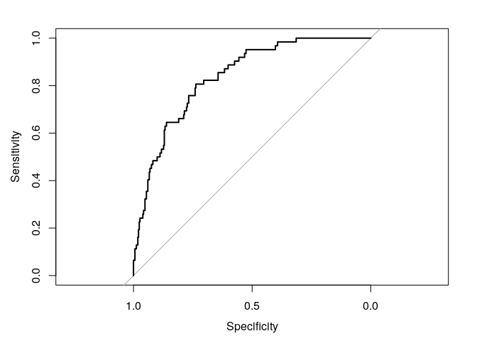

```r
roc_class <- roc(test$match, preds.per)
plot(roc_class)
```

Since we are trying to predict a match between two dating persons, we decided that a high accuracy is not important, but that a high Sensitivty is more relevant, since going to a nother date with a person you don’t like is not as bad as missing out on a pontential partner. Here is the density plot for our latest fold.

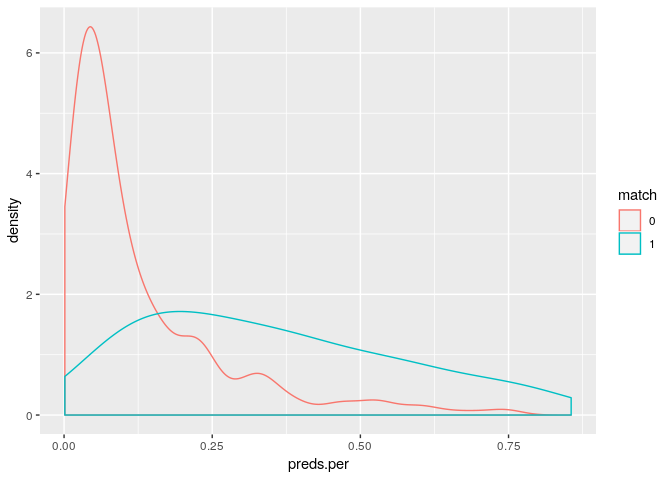

```r
test$preds_score = preds.per
dual_density <- ggplot(test) + geom_density(aes(x = preds.per, color = match))
plot(dual_density)
```

We calculate the average threshhold which maximize our Sensitivity and Specificity.

```r
threshhold = as.numeric(optim.thresh(test$match, preds.per )['max.sensitivity+specificity'])

print(threshhold)
```

```
## [1] 0.16
```

Using this threshhold here are our final results in form of a confusion matrix.

```r
pred_int <- preds.per
pred_int[pred_int >= threshhold] = 1
pred_int[pred_int < threshhold] = 0
pred_int <- as.factor(pred_int)
print(confusionMatrix(pred_int, test$match, positive = "1"))
```

```
## Confusion Matrix and Statistics
##
##           Reference
## Prediction   0   1
##          0 245  13
##          1  86  49
##
##                Accuracy : 0.7481
##                  95% CI : (0.7021, 0.7903)
##     No Information Rate : 0.8422
##     P-Value [Acc > NIR] : 1
##
##                   Kappa : 0.3588
##  Mcnemar's Test P-Value : 4.612e-13
##
##             Sensitivity : 0.7903
##             Specificity : 0.7402
##          Pos Pred Value : 0.3630
##          Neg Pred Value : 0.9496
##              Prevalence : 0.1578
##          Detection Rate : 0.1247
##    Detection Prevalence : 0.3435
##       Balanced Accuracy : 0.7653
##
##        'Positive' Class : 1
##
```